# Probability Review

# Plotting the Standard Normal pdf

The `dnorm()` function computes the pdf of the standard normal distribution.

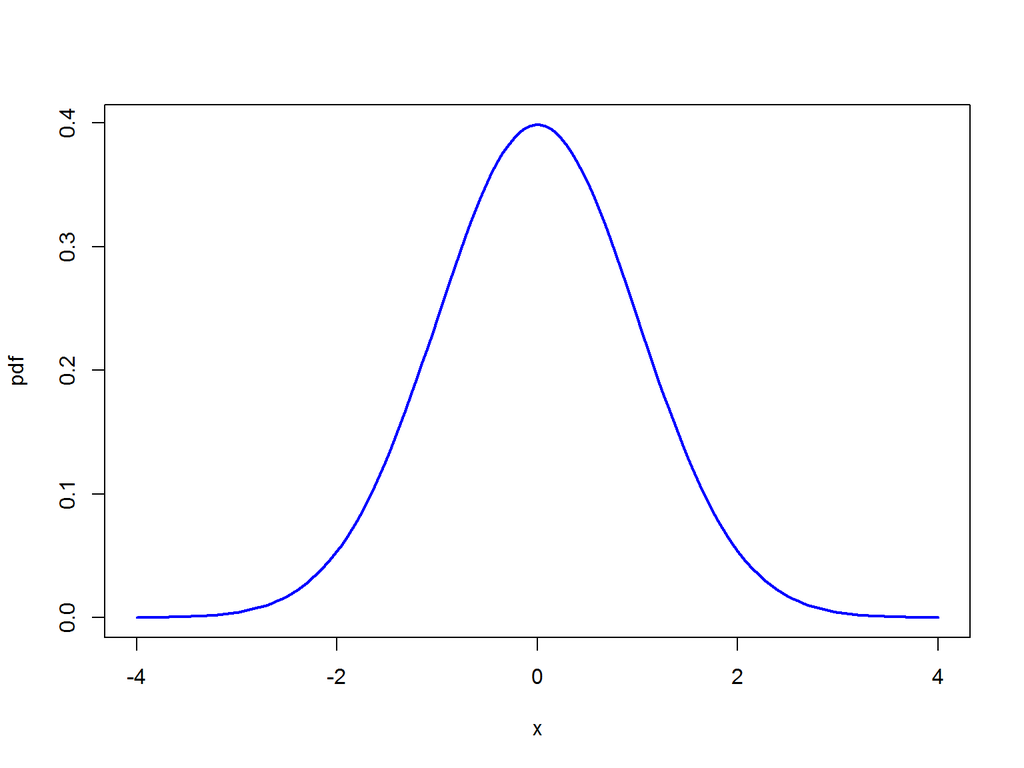

```r
# determine range of values for which to plot pdf and CDF
x.vals = seq(-4, 4, length=150)
# plot pdf
plot(x.vals, dnorm(x.vals), type="l", lwd=2,
     col="blue", xlab="x", ylab="pdf")
```

# Shading a Region Under the Standard Normal Curve

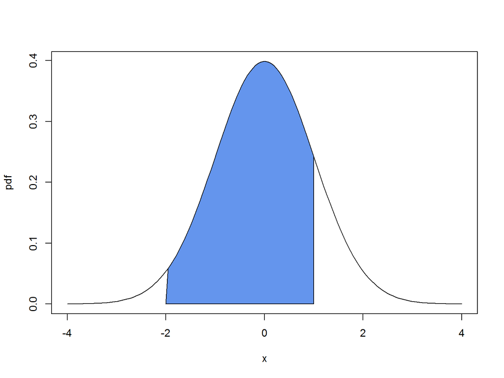

```r
lb = -2
ub = 1
x.vals = seq(-4, 4, length=150)
d.vals = dnorm(x.vals)
# plot normal density
plot(x.vals, d.vals, type="l", xlab="x", ylab="pdf")
i = x.vals >= lb & x.vals <= ub
# add shaded region between -2 and 1
polygon(c(lb, x.vals[i], ub), c(0, d.vals[i], 0), col="cornflowerblue")
```

# Plotting the Standard Normal CDF

The `pnorm()` function computes the CDF of the standard normal distribution.

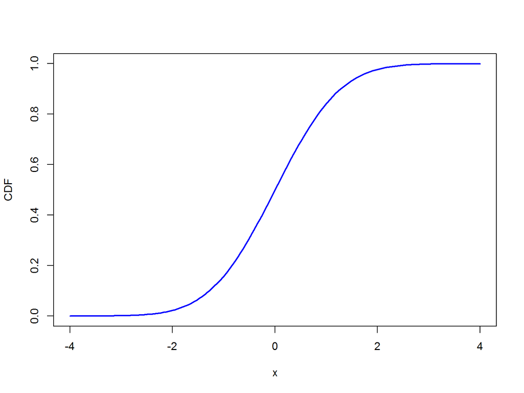

```r
# plot CDF
plot(x.vals, pnorm(x.vals), type="l", lwd=2,
     col="blue", xlab="x", ylab="CDF")
```

# The Normal Distribution for Monthly Returns

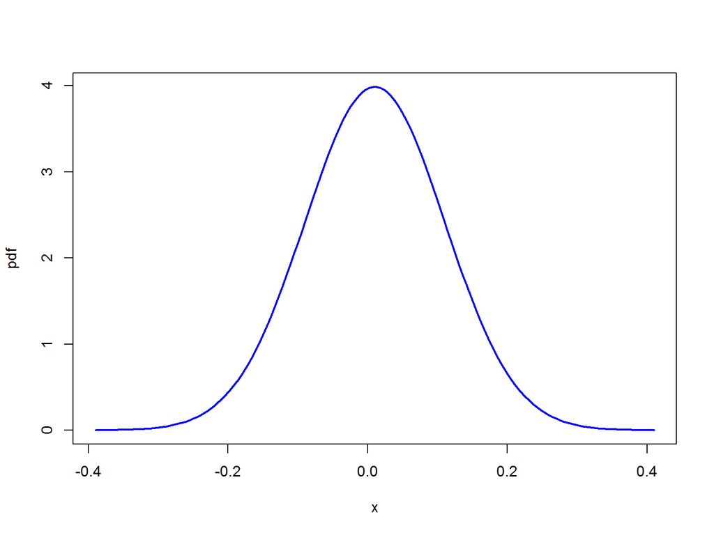

```r
mu.r = 0.01
sd.r = 0.1
x.vals = seq(-4, 4, length=150)*sd.r + mu.r
plot(x.vals, dnorm(x.vals, mean=mu.r, sd=sd.r), type="l", lwd=2,
     col="blue", xlab="x", ylab="pdf")
```

Calculate probabilities: $Pr(R < -0.5), Pr(R < 0), Pr(R > 0.5) and Pr(R > 1)$

```r
pnorm(-0.5, mean=0.01, sd=0.1)
```

```
## [1] 1.7e-07
```

```r
pnorm(0, mean=0.01, sd=0.1)
```

```
## [1] 0.46
```

```r
1 - pnorm(0.5, mean=0.01, sd=0.1)
```

```
## [1] 4.79e-07
```

```r
1 - pnorm(1, mean=0.01, sd=0.1)
```

```
## [1] 0
```

Calculate the quantiles: $q_{0.01}, q_{0.05}, q_{0.95}, q_{0.99}$

```r
a.vals = c(0.01, 0.05, 0.95, 0.99)
qnorm(a.vals, mean=0.01, sd=0.10)
```

```
## [1] -0.223 -0.154  0.174  0.243
```

# Risk-Return Tradeoff

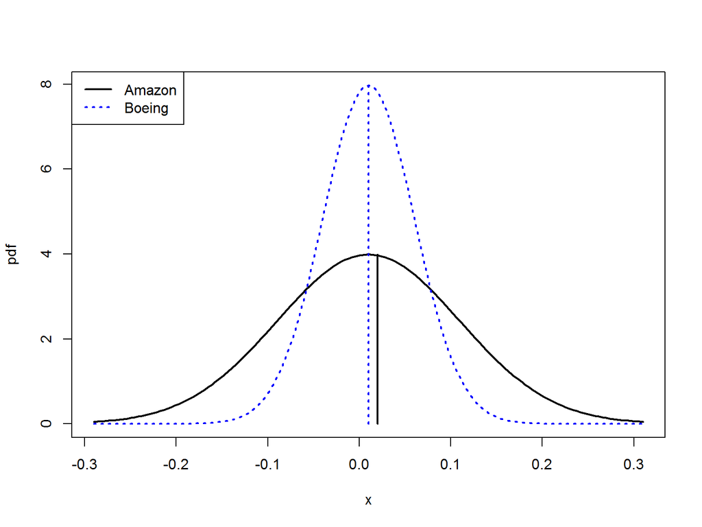

```r
sd.r = 0.10
x.vals = seq(-3, 3, length=150)*sd.r + mu.r
plot(x.vals, dnorm(x.vals, mean=mu.r, sd=sd.r), type="l", lwd=2,
     ylim=c(0, max(dnorm(x.vals, mean=0.01, sd=0.05))),
     col="black", xlab="x", ylab="pdf")
points(x.vals, dnorm(x.vals, mean=0.01, sd=0.05), type="l", lwd=2,
       col="blue", lty="dotted")
segments(0.02, 0, 0.02, dnorm(0.02, mean=0.02, sd=0.1), lwd=2)
segments(0.01, 0, 0.01, dnorm(0.01, mean=0.01, sd=0.05), lwd=2,
         col="blue", lty="dotted")
legend(x="topleft", legend=c("Amazon", "Boeing"), lwd=2,
       col=c("black", "blue"), lty=c("solid","dotted"))
```

# Log-Normal Distribution

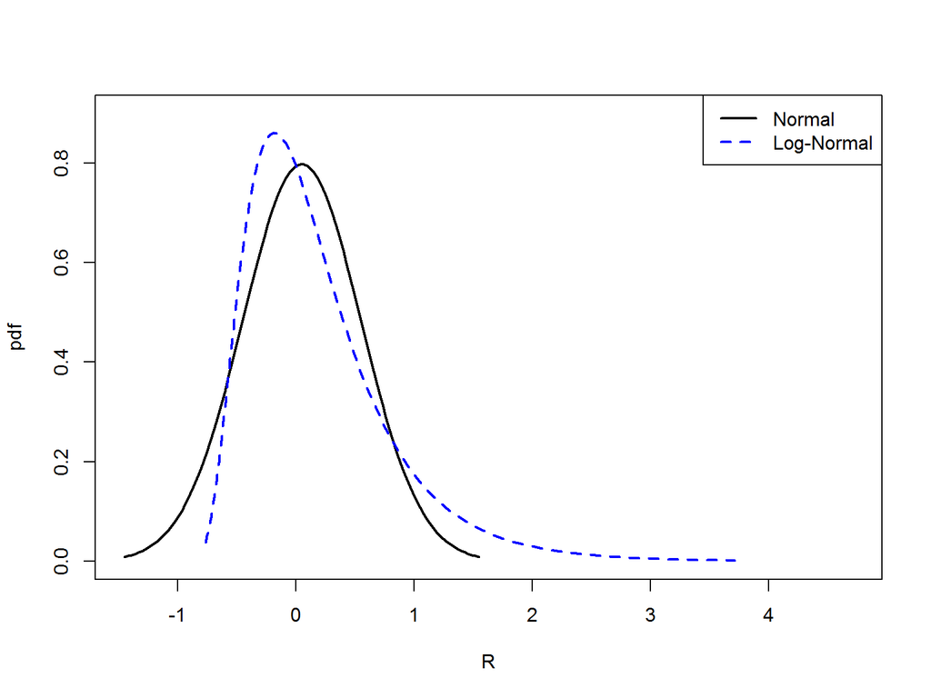

```r
mu.x = 0.05
sd.x = 0.5
x.vals = seq(from=(mu.x - 3*sd.x), to=(mu.x + 3*sd.x), length = 100)
plot(x.vals, dnorm(x.vals, mean=mu.x, sd=sd.x), type="l", lwd=2,
     xlim = c(min(x.vals), max(exp(x.vals))),
     ylim = c(0, 0.9),
     xlab="R", ylab="pdf")
points(exp(x.vals)-1, dlnorm(exp(x.vals), mean=mu.x, sd=sd.x), type="l",
       lwd = 2, col="blue", lty="dashed",
     xlab="1 + R", ylab="density", main="Log-Normal(0.05, (0.5)^2)")
legend(x="topright", legend=c("Normal", "Log-Normal"), lwd=2,
       col=c("black", "blue"), lty = c("solid", "dashed"))
```

# Illustration of Skewed Distributions

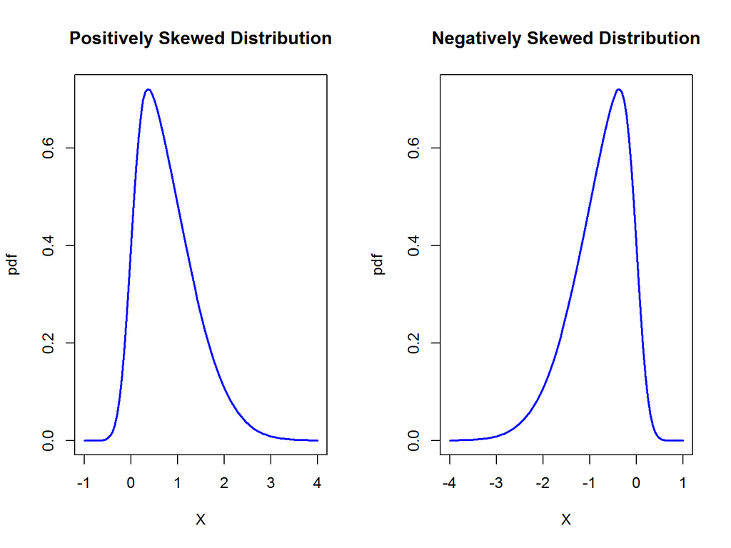

# Student’s t Distribution

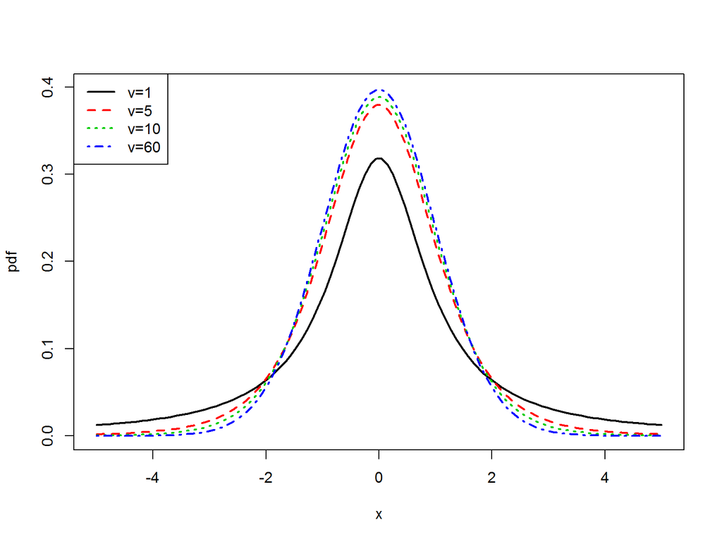

# Value-at-Risk Calculations for Simple Returns

Let $R$ denote the simple monthly return on Microsoft stock and assume that $R\sim N(0.05,(0.10)^{2}$. Consider an initial investment of $W_{0}=\$10,000$. To compute the 1% and 5% VaR values over the next month use:

```r
mu.R = 0.05
sd.R = 0.10
w0 = 10000
q.01.R = mu.R + sd.R*qnorm(0.01)
q.05.R = mu.R + sd.R*qnorm(0.05)
VaR.01 = abs(q.01.R*w0)
VaR.05 = abs(q.05.R*w0)
VaR.01
```

```
## [1] 1826
```

```r
VaR.05
```

```
## [1] 1145
```

Hence with 1% and 5% probability the loss over the next month is at least $1,826 and $1,145, respectively.

# Value-at-Risk calculations for cc Returns

Let $r$ denote the continuously compounded return on Microsoft stock and assume that $r\sim N(0.05,(0.10)^{2})$. To compute the 1% and 5% VaR values over the next month use:

```r
mu.r = 0.05
sd.r = 0.10
q.01.R = exp(mu.r + sd.r*qnorm(0.01)) - 1
q.05.R = exp(mu.r + sd.r*qnorm(0.05)) - 1
VaR.01 = abs(q.01.R*w0)
VaR.05 = abs(q.05.R*w0)
VaR.01
```

```
## [1] 1669
```

```r
VaR.05
```

```
## [1] 1082
```

Notice that when $1+R=e^{r}$ has a log-normal distribution, the 1% and 5% VaR values (losses) are slightly smaller than when $R$ is normally distributed. This is due to the positive skewness of the log-normal distribution.

# Illustrate Covariance

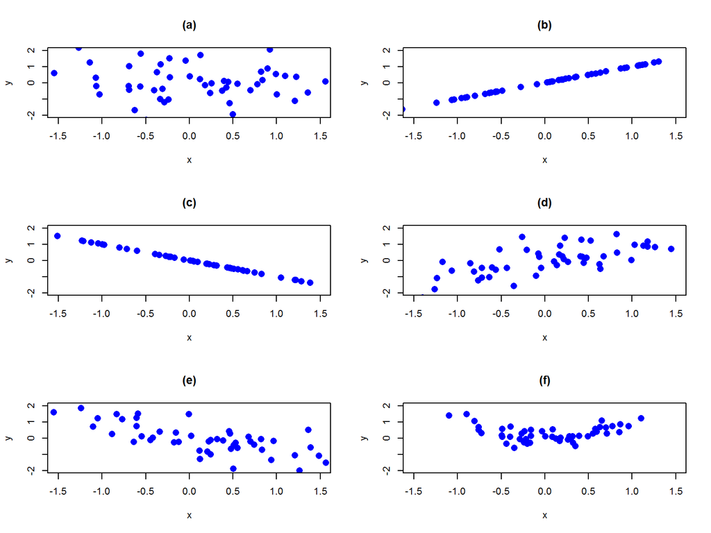

- Panel (a) Zero covariance (no linear relationship): cov(X,Y) = 0
- Panel (b) Perfect positive linear relationship: cov(X,Y) > 0
- Panel (c) Perfect negative linear relationship: cov(X,Y) < 0
- Panel (d) moderate positive linear relationship: cov(X,Y) > 0
- Panel (e) moderate negative linear relationship: cov(X,Y) < 0
- Panel (f) Nonlinear relationship: cov(X,Y) = 0

# Illustrate Covariance

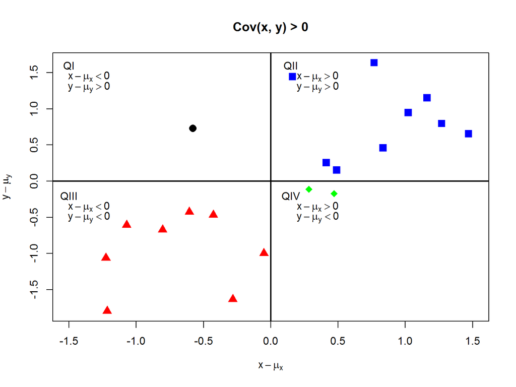

- QI: contributions to covariance are negative (black dots)
- QII: contributions to covariance are positive (blue squares)
- QIII: contributions to covariance are positive (red triangles)
- QIV: contributions to covariance are negative (green diamonds)
- Here, sum of all contributions is positive so cov(X,Y) > 0

# Bivariate Normal Distribution

Here is a plot of the bivariate normal pdf with parameters $\mu_{X}=\mu_{Y}=0, \sigma_{X}=\sigma_{Y}=1$ and $\rho=0.5$.

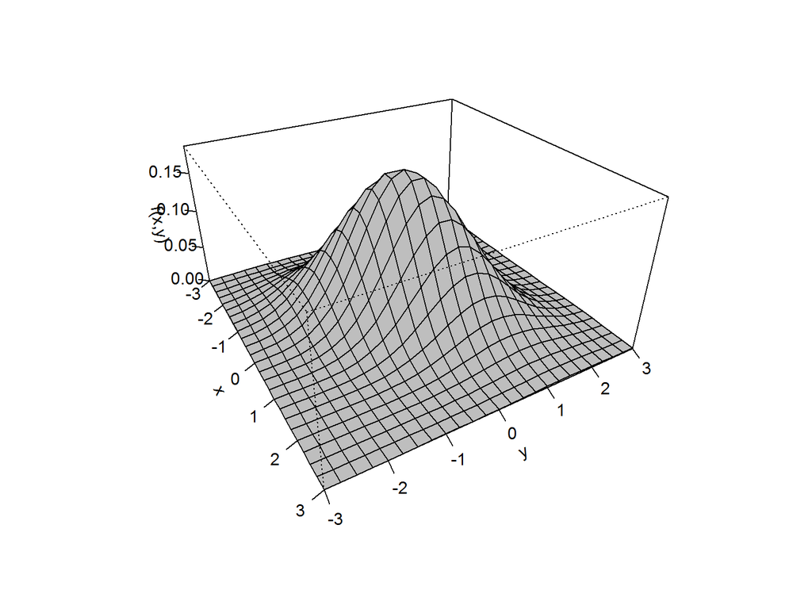